# Clustering BRCA samples based on cooperatively regulated CE and ALE events

Mario Keller

Faculty of Biological Sciences, Goethe University Frankfurt

10 August 2026

```r
knitr::opts_chunk$set(echo = TRUE, message=FALSE, warning=FALSE,
                      crop=NULL, results = TRUE)
```

```r
library(tidyverse)
library(ComplexHeatmap)
library(circlize)
library(RColorBrewer)
library(DESeq2)
library(knitr)
library(ggbeeswarm)
library(kableExtra)
library(missMDA)
library(matrixStats)
library(TCGAbiolinks)
```

```r
myTheme <- theme_bw() +
    theme(axis.text = element_text(size = 14, colour="black"),
          axis.title = element_text(size=16, colour="black"),
          axis.ticks=element_line(color="black"),
          axis.ticks.length=unit(.15, "cm"),
          panel.border=element_rect(color="black", fill = NA),
          panel.background = element_blank(),
          plot.background = element_blank(),
          legend.text = element_text(size=12),
          legend.position = "none")
```

```r
projectDir <- "/Users/jb/data/HNPRNPH/Tretow_et_al_2023"

majiqDir <- paste0(projectDir, "/2_MAJIQ_AS_analysis")
tcgaDir <- paste0(projectDir, "/8_TCGA_analysis")
```

# 1 Background

In *Correlation_HNRNPH_levels_and_splicing_events.Rmd* it could be shown that at least HNRNPH2 showed the expected correlation with the cooperatively regulated CE and ALE events. As a final analysis we wanted to know whether PSI levels of the regulated events are different between normal and tumor samples as well as between PAM50 subtypes and, if so, whether they could be used for the discrimination of normal from tumor samples as well as of PAM50 subtypes.

# 2 Data

Vst-transformed and batch corrected expression values are loaded from a RDS-File created with *Calculate_expression_BRCA.R*.

Sample meta information is loaded from a RDS-File created with *Calculate_expression_BRCA.R*.

PSI values of junctions of interest are loaded from a RDS-File created with *Calculate_PSIs_BRCA.R*.

Regulated CE and ALE events are loaded from a RDS-File created with *MAJIQ_AS_analysis.Rmd*.

```r
vsdBatchCorrected<- readRDS(paste0(tcgaDir,"/rds_files/BRCA_vsdBatchCorrected.rds"))

metaInformation <- readRDS(paste0(tcgaDir,"/rds_files/BRCA_metaInformation.rds"))

PSIs <- readRDS(paste0(tcgaDir,"/rds_files/BRCA_PSI.rds"))

regulatedCEs <- readRDS(paste0(majiqDir,"/rds_files/regulatedCEs.rds"))
regulatedALEs <- readRDS(paste0(majiqDir,"/rds_files/regulatedALEs.rds"))
```

A data.frame with the expression levels of HNRNPH1 (ENSG00000169045.17) and HNRNPH2 (ENSG00000126945.8) is created.

```r
# Each row is a sample and columns are the samplebarcode and HNRNPH1 and HNRNPH2
#   expression levels
HNRNPHexpression <- data.frame(geneName=c("HNRNPH1", "HNRNPH2"),
                               vsdBatchCorrected[match(c("ENSG00000169045.17",
                                                         "ENSG00000126945.8"),
                                                       rownames(vsdBatchCorrected)),] %>%
                                   assay) %>%
    pivot_longer(., cols=-1, names_to="tcgaSampleBarcode", values_to="vst") %>%
    mutate(tcgaSampleBarcode=gsub(".", "-", tcgaSampleBarcode, fixed = T)) %>%
    pivot_wider(., names_from = geneName, values_from=vst)

# The participant barcode and the sample type are added
HNRNPHexpression <- HNRNPHexpression %>%
    left_join(., metaInformation %>% dplyr::select(tcga.tcga_barcode,
                                                   tcga.gdc_cases.submitter_id,
                                                   tcga.gdc_cases.samples.sample_type),
              by=c("tcgaSampleBarcode" = "tcga.tcga_barcode")) %>%
    dplyr::rename(tcgaPatientBarcode = tcga.gdc_cases.submitter_id,
           sampleType = tcga.gdc_cases.samples.sample_type)
```

PSI quantifications of the HNRNPH1 NMD isoform is extracted and stored separately.

```r
HNRNPH1nmdIsoformPSIs <- PSIs %>% dplyr::filter(eventType == "HNRNPH1nmdIsoform")
```

Splicing events are reduced to those of the category “Coop-Enh” and “Coop-Rep”.

```r
# Remove the quantifications of the HNRNPH1 NMD isoform and
#   the non-regulated CE events
PSIs <- PSIs %>%
    dplyr::filter(hillCat %in% c("Coop-Enh", "Coop-Rep"))
```

For the upcoming analyses events with too many NAs and low dynamic are a problem. For this purpose, all events quantified in < 100 samples and those that have across all patients less than 10 different PSI values are removed. The latter one are cases where for instance all patients have full inclusion.

```r
keep1 <- PSIs %>%
    dplyr::count(eventID) %>%
    dplyr::filter(n >= 100) %>%
    pull(eventID)

keep2 <- PSIs %>%
    dplyr::count(eventID, PSI) %>%
    dplyr::count(eventID) %>%
    dplyr::filter(n >= 10) %>%
    pull(eventID)

keep <- intersect(keep1, keep2)

PSIs <- PSIs %>% dplyr::filter(eventID %in% keep)
```

This procedure left 302 events.

# 3 Preparation of the matrix and annotation vectors

As some of the 302 events have no quantification in some of the samples, their PSI values are imputed using the *imputePCA()* function of the *missMDA* package.

```r
# The PSI data.frame is turned into a matrix with 302 rows (events) and
#   1177 columns (BRCA samples)
mat <- PSIs %>%
    dplyr::select(eventID, tcgaSampleBarcode, PSI) %>%
    arrange(eventID, tcgaSampleBarcode) %>%
    pivot_wider(names_from=tcgaSampleBarcode, values_from = PSI) %>%
    column_to_rownames("eventID") %>%
    as.matrix

# Missing values are imputed
mat <- imputePCA(mat %>% t, ncp=2)
mat <- mat$completeObs %>% t

# Z-score transformation
matZscore <- (mat  - (mat %>% rowMeans(., na.rm=T))) / rowSds(mat, na.rm=T)
```

In the final Heatmap column as well as row annotation should be shown. These will include:

Column (samples):

- The Inclusion levels of the HNRNPH1 NMD isoform (high = functional, low = NMD)
- *HNRNPH1* expression levels
- *HNRNPH2* expression levels
- Sample type (Primary Tumor and Solid Tissue Normal)
- PAM50 subtype (Basal, Her2, LumA, LumB and Normal)

Row (events):

- Hill category (Coop-Enh and Coop-Rep)
- $\Delta$PSI in the strongest knockdown (10 nM)

```r
# Column

# HNRNPH1 NMD isoform levels. Note that 9 samples have no quantification
#   leading to a NA in the vector
colAnnoHNRNPH1nmd <- HNRNPH1nmdIsoformPSIs$PSI[
    match(colnames(matZscore),HNRNPH1nmdIsoformPSIs$tcgaSampleBarcode)]

# HNRNPH1/2 expression
colAnnoHNRNPH1expr <- HNRNPHexpression$HNRNPH1[
    match(colnames(matZscore), HNRNPHexpression$tcgaSampleBarcode)]
colAnnoHNRNPH2expr <- HNRNPHexpression$HNRNPH2[
    match(colnames(matZscore), HNRNPHexpression$tcgaSampleBarcode)]

# sample type
colAnnoSampleType <- PSIs$sampleType[
    match(colnames(matZscore), PSIs$tcgaSampleBarcode)]

# PAM50 subtype via PanCancerAtlas_subtypes() of the TCGAbiolinks package
colAnnoPAM50subtype <- PanCancerAtlas_subtypes() %>%
    dplyr::filter(cancer.type=="BRCA")
colAnnoPAM50subtype <- colAnnoPAM50subtype$Subtype_mRNA[
    match(colnames(matZscore),colAnnoPAM50subtype$pan.samplesID)]

# Row

#  Hill category
rowAnnoHillCategory <- PSIs$hillCat[match(rownames(matZscore), PSIs$eventID)]

# Strongest knockdown
rowAnnoStongestKD <- rbind(
    regulatedCEs %>%
        dplyr::select(event_id, KD_10000.KD_Contr_median_dpsi),
    regulatedALEs %>%
        dplyr::select(event_id, KD_10000.KD_Contr_median_dpsi))

rowAnnoStongestKD <- rowAnnoStongestKD$KD_10000.KD_Contr_median_dpsi[
    match(rownames(matZscore), rowAnnoStongestKD$event_id)]
```

# 4 Heatmap with Clustering

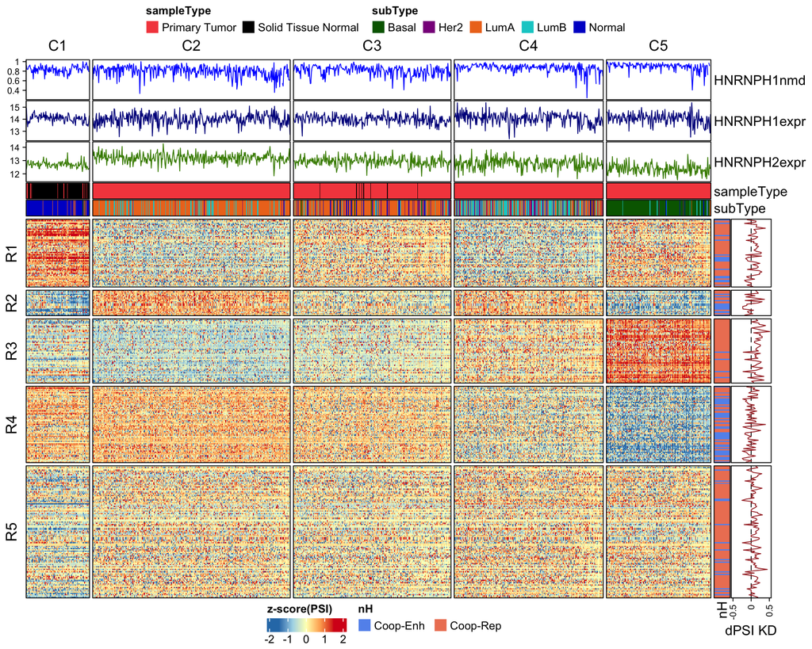

```r
myCol <- colorRamp2(c(-1.5, -.75, 0, .75, 1.5),
                    brewer.pal(n = 5, name = "RdYlBu") %>% rev)

colAnno = HeatmapAnnotation(
    HNRNPH1nmd = anno_lines(colAnnoHNRNPH1nmd, gp = gpar(col = "blue"),
                            height = unit(1.25, "cm")),
    HNRNPH1expr = anno_lines(colAnnoHNRNPH1expr, gp = gpar(col = "blue4"),
                             height = unit(1.25, "cm")),
    HNRNPH2expr = anno_lines(colAnnoHNRNPH2expr, gp = gpar(col = "chartreuse4"),
                             height = unit(1.25, "cm")),
    sampleType = colAnnoSampleType,
    subType = colAnnoPAM50subtype,
    col=list(sampleType = c("Solid Tissue Normal" = "black",
                            "Primary Tumor" = "#f54c4c"),
             subType = c("Normal"="blue3", "LumA"="chocolate2",
                         "LumB"="cyan3", "Her2"="darkmagenta",
                         "Basal"="darkgreen", "NA"="grey")),
    show_annotation_name=T, border=T,
    annotation_legend_param=list(nrow=1))

rowAnno = rowAnnotation(hillCat = rowAnnoHillCategory,
                        strongestKDpsi = anno_lines(cbind(0, rowAnnoStongestKD),
                                                    gp = gpar(col = c("black", "brown"),
                                                              lty=c("dashed", "solid")),
                                                    width = unit(1.25, "cm"),
                                                    ylim=c(-.5, .5)),
                        col=list(hillCat=c("Coop-Enh"="cornflowerblue",
                                           "Coop-Rep"="salmon2")),
                        show_annotation_name=T, border=T,
                        annotation_label=c("nH", "dPSI KD"),
                        annotation_legend_param=list(nrow=1))

set.seed(1)
colClusters <- kmeans(matZscore %>% t, centers=5)
colClusterRenaming <- c("C1" = 1, "C2" = 3, "C3" = 2, "C4" = 4, "C5" = 5)
colClusters$cluster <- names(colClusterRenaming)[match(colClusters$cluster,
                                                             colClusterRenaming)]

rowClusters <- kmeans(matZscore, centers=5)
rowClusterRenaming <- c("R1" = 2, "R2" = 1, "R3" = 4, "R4" = 5, "R5" = 3)
rowClusters$cluster <- names(rowClusterRenaming)[match(rowClusters$cluster,
                                                       rowClusterRenaming)]

hm <- Heatmap(matZscore,  col=myCol,
              cluster_rows = F, cluster_columns = F,
              show_row_names =F, show_column_names = F,
              show_row_dend = F, show_column_dend = F,
              row_split = rowClusters$cluster, cluster_row_slices = T,
              column_split = colClusters$cluster, cluster_column_slices = T,
              top_annotation = colAnno, right_annotation = rowAnno,
              row_names_gp = gpar(fontsize = 3),
              heatmap_legend_param = list(legend_direction = "horizontal",
                                          title="z-score(PSI)"),
              border=T, use_raster = TRUE, raster_quality = 5)

draw(hm, annotation_legend_side = "top", heatmap_legend_side="bottom")
```

# 5 Summary of row and column annotations

From the Heatmap annotations certain trends can be captured for row and column clusters such as lower HNRNPH2 levels for the clusters C1 and C5.

To better capture these trends and differences between clusters, each row and column annotation is examined in more detail.

## 5.1 HNRNPH1 NMD isoform and HNRNPH1/2 expression levels

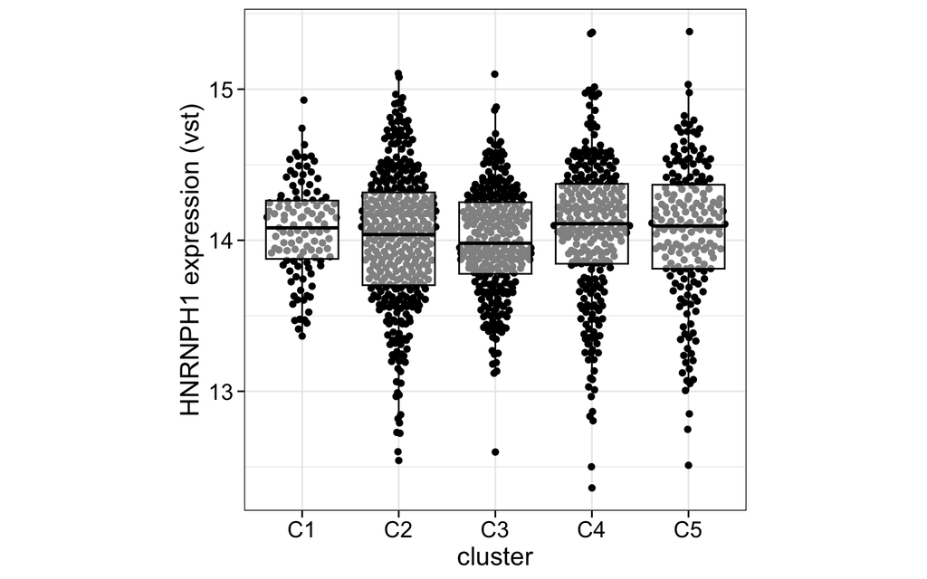

```r
data.frame(HNRNPH1expr=colAnnoHNRNPH1expr,
           cluster=factor(colClusters$cluster, levels=paste0("C", 1:5))) %>%
    ggplot(., aes(x=cluster, y=HNRNPH1expr)) + #, fill=gene, col=gene)) +
        geom_quasirandom() +
        geom_boxplot(alpha=.5, outlier.size = -1, col="black") +
        labs(y="HNRNPH1 expression (vst)") +
        myTheme + theme(aspect.ratio=1)
```

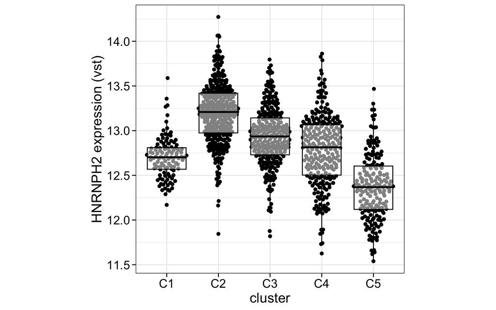

```r
data.frame(HNRNPH2expr=colAnnoHNRNPH2expr,
           cluster=factor(colClusters$cluster, levels=paste0("C", 1:5))) %>%
    ggplot(., aes(x=cluster, y=HNRNPH2expr)) + #, fill=gene, col=gene)) +
        geom_quasirandom() +
        geom_boxplot(alpha=.5, outlier.size = -1, col="black") +
        labs(y="HNRNPH2 expression (vst)") +
        myTheme + theme(aspect.ratio=1)
```

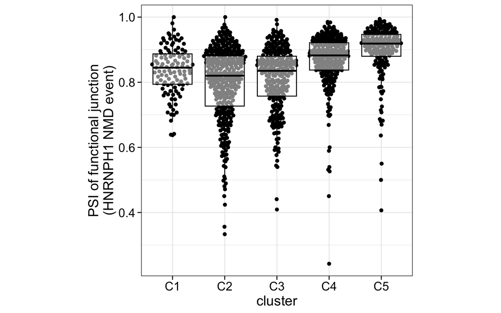

```r
data.frame(HNRNPH1nmd=colAnnoHNRNPH1nmd,
           cluster=factor(colClusters$cluster, levels=paste0("C", 1:5))) %>%
    ggplot(., aes(x=cluster, y=HNRNPH1nmd)) + #, fill=gene, col=gene)) +
        geom_quasirandom() +
        geom_boxplot(alpha=.5, outlier.size = -1, col="black") +
        labs(y="PSI of functional junction\n(HNRNPH1 NMD event)") +
        myTheme + theme(aspect.ratio=1)
```

## 5.2 Fraction of PAM50 subtypes

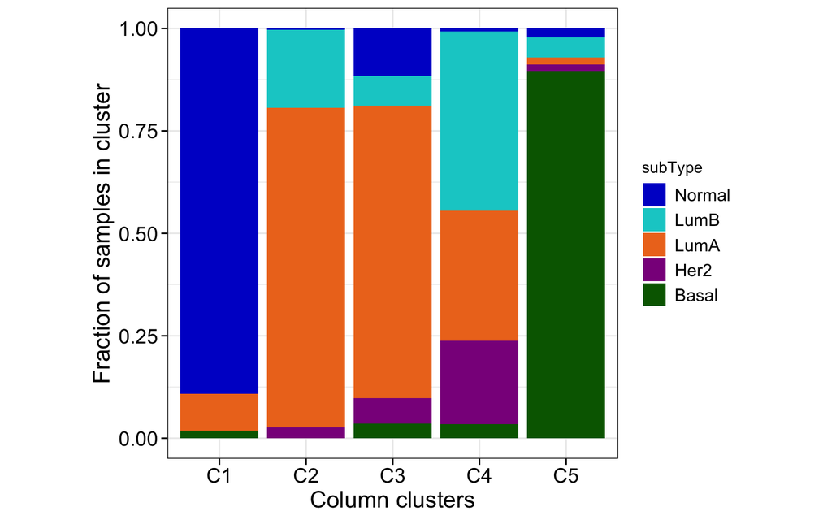

```r
data.frame(subType=factor(colAnnoPAM50subtype,
                          levels=c("Basal", "Her2", "LumA",
                                   "LumB", "Normal") %>% rev),
           cluster=factor(colClusters$cluster, levels=paste0("C", 1:5))) %>%
    ggplot(., aes(x=cluster, fill=subType)) + #, fill=gene, col=gene)) +
        geom_bar(position="fill") +
        scale_fill_manual(values=c("Normal"="blue3", "LumA"="chocolate2",
                                   "LumB"="cyan3", "Her2"="darkmagenta",
                                   "Basal"="darkgreen", "NA"="grey")) +
        labs(y="Fraction of samples in cluster", x="Column clusters") +
        myTheme + theme(legend.position = "right", aspect.ratio = 1)
```

## 5.3 Fraction of enhanced and repressed events

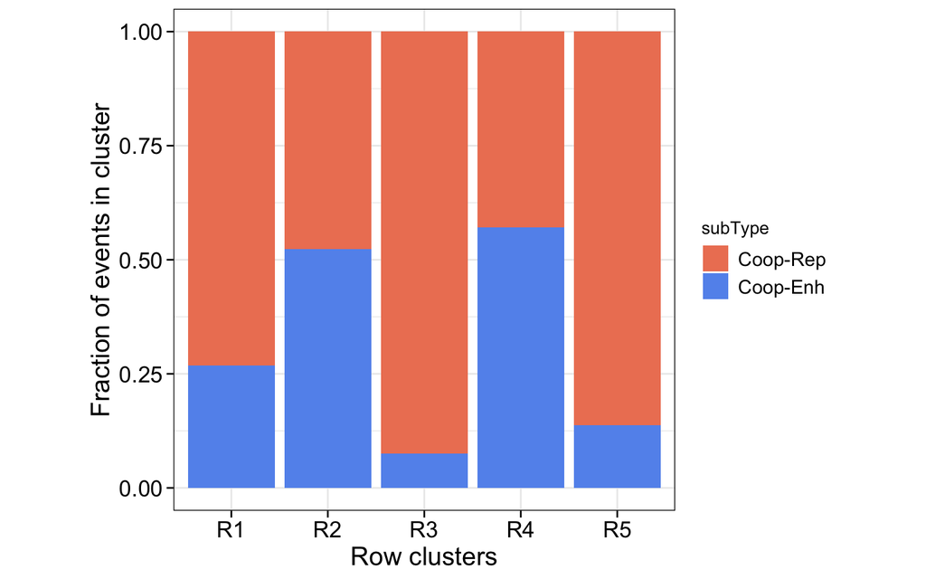

```r
data.frame(subType=factor(rowAnnoHillCategory, levels=c("Coop-Rep",
                                                        "Coop-Enh")),
           cluster=factor(rowClusters$cluster, levels=paste0("R", 1:5))) %>%
    ggplot(., aes(x=cluster, fill=subType)) + #, fill=gene, col=gene)) +
        geom_bar(position="fill") +
        scale_fill_manual(values=c("Coop-Enh"="cornflowerblue",
                                   "Coop-Rep"="salmon2")) +
        labs(y="Fraction of events in cluster", x="Row clusters") +
        myTheme + theme(legend.position = "right", aspect.ratio = 1)
```

## 5.4 Effect of strongest knockdown (10 nM)

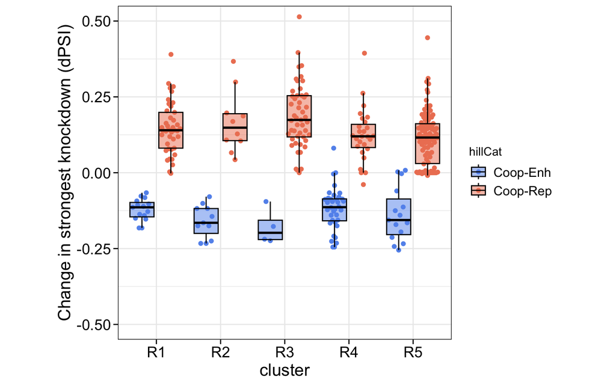

```r
data.frame(knockdowndPSI=rowAnnoStongestKD,
           hillCat = rowAnnoHillCategory,
           cluster=factor(rowClusters$cluster,levels=paste0("R", 1:5)))  %>%
ggplot(., aes(x=cluster, y=knockdowndPSI, fill=hillCat, col=hillCat)) +
    geom_quasirandom(dodge.width = 0.9) +
    geom_boxplot(alpha=.5, outlier.size = -1, col="black",
                 position = position_dodge(width = 0.9)) +
    coord_cartesian(ylim=c(-.5, .5)) +
    scale_color_manual(values=c("Coop-Enh"="cornflowerblue",
                                "Coop-Rep"="salmon2")) +
    scale_fill_manual(values=c("Coop-Enh"="cornflowerblue",
                               "Coop-Rep"="salmon2")) +
    labs(y="Change in strongest knockdown (dPSI)") +
    myTheme + theme(legend.position = "right", aspect.ratio = 1)
```

## 5.5 Z-scored PSIs

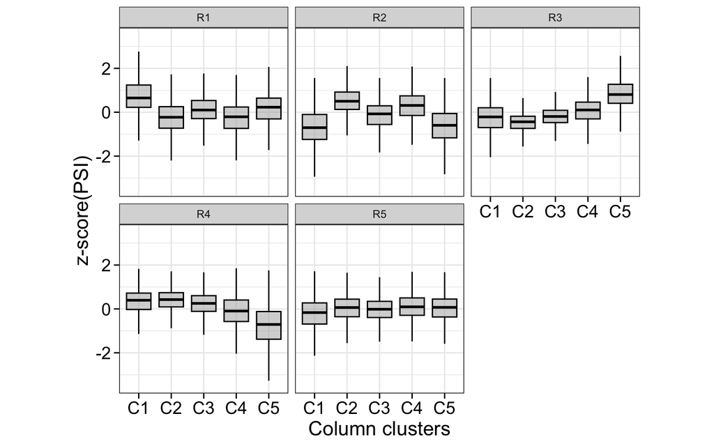

```r
lapply(1:nrow(matZscore), function(i){
    data.frame(columnCluster=colClusters$cluster,
               rowCluster=rowClusters$cluster[i],
               zPSI=matZscore[i,])
}) %>% bind_rows() %>%
    ggplot(., aes(x=columnCluster, y=zPSI)) +
    geom_boxplot(alpha=.5, outlier.size = -1, col="black", fill="darkgrey") +
    coord_cartesian(ylim=c(-3.5, 3.5)) +
    labs(y="z-score(PSI)", x="Column clusters") +
    facet_wrap(~rowCluster) +
    myTheme + theme(aspect.ratio = 1)
```

# 6 Quality of clustering

From the Heatmap it became clear that the cooperatively regulated CE and ALE events have the potential to separater normal from tumor samples as well as to separate the Basal subtype samples from the other samples.

One way to quantify the separation capability is the adjusted Rand index, which was designed to compare two classifications. The adjusted Rand index was compute once for the separation of normal from tumor samples and once for the separation of the Basal subtype samples from the other samples. To test whether the cooperatively regulated events lead to a better separation than a set of random splicing events, 100 sets of randomly picked non-regulated CE events with a similar set size were used for clustering and calculation of the two adjusted Rand indices. The calculation was done in the Rscript called *Calculate_adjusted_Rand_Indices.R*

The following procedure was followed for the set of cooperatively regulated CE and ALE events and the 100 random sets of non-regulated CE events.

1. Create a PSI matrix (rows are the events and columns the BRCA samples)
2. Impute missing values in the matrix
3. Z-score transformation
4. For each column (BRCA sample) store the sample type and PAM50 subtype
5. Perform k-means clustering (k=5)
6. Adjusted Rand Index for the separation of normal from tumor samples
   1. Determine the cluster with the highest number of normal samples and label it as “C_Normal”
   2. All other clusters are labeled as “C_Other”
   3. Calculate the adjusted Rand Index by using the sample type (normal and tumor) as first class label and the new cluster labels (C_Normal and C_Other) as second class label
7. Adjusted Rand Index for the separation of Basal subtype samples from the other samples
   1. Determine the cluster with the highest number of Basal subtype samples and label it as “C_Basal”
   2. All other clusters are labeled as “C_Other”
   3. Change the PAM50 subtype of samples other than Basal to “Other”
   4. Calculate the adjusted Rand Index by using the PAM50 subtype (Basal and Other) as first class label and the new cluster labels (C_Basaland C_Other) as second class label

An adjusted Rand index of 0 means random partition, while a value of 1 means perfect agreement (separation). Below is a scatterplot showing the adjusted Rand index for the separation of the normal samples on th x-axis and the adjusted Rand index for the separation of the Basal subtype samples on the y-axis. Shown is the set of cooperarively regulated CE and ALE events (the ones from the Heatmap above) and the 100 sets of randomly picked non-regulated CE events. One can nicely see that the regulated events achieve for both adjusted Rand indices the highest value, meaning they achieve a better separation than random splicing events.

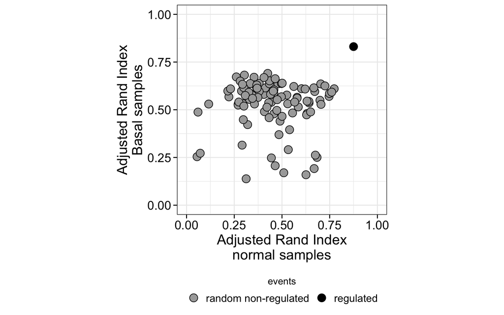

```r
adjustedRandIndices <- readRDS(paste0(tcgaDir,
                                      "/rds_files/adjustedRandIndices.rds"))

adjustedRandIndices <- adjustedRandIndices %>%
    mutate(setLabel = ifelse(setLabel == "reg",
                             "regulated",
                             "random non-regulated"))

adjustedRandIndices %>%
        ggplot(., aes(x=normalAdjustedRandIndex, y=basalAdjustedRandIndex, fill=setLabel)) +
        geom_point(size=4, shape=21) +
        scale_fill_manual("events", values=c("regulated" = "black",
                                             "random non-regulated" = "darkgrey")) +
        coord_cartesian(xlim=c(0, 1), ylim=c(0, 1)) +
        myTheme + theme(legend.position = "bottom", aspect.ratio=1) +
        labs(x="Adjusted Rand Index\nnormal samples",
             y="Adjusted Rand Index\nBasal samples") +
        guides(fill = guide_legend(title.position = "top", title.hjust = 0.5))
```

# 7 Survival analysis

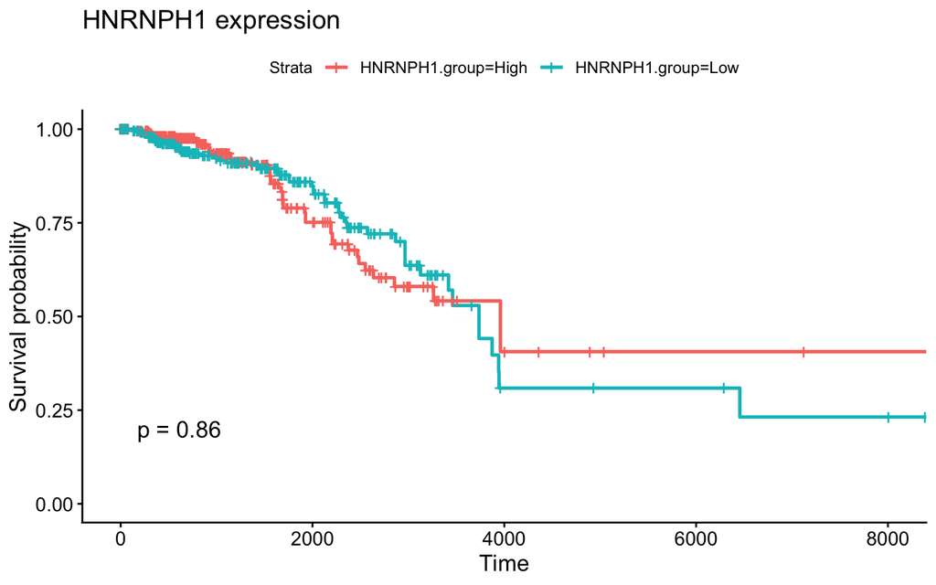

```r
library(survival)
library(survminer)

df <- HNRNPHexpression %>% left_join(metaInformation, by = c("tcgaPatientBarcode" = "tcga.xml_bcr_patient_barcode")) %>%
    filter(sampleType == "Primary Tumor") %>%
    mutate(OS.time = coalesce(tcga.gdc_cases.diagnoses.days_to_death, tcga.gdc_cases.diagnoses.days_to_last_follow_up),
           OS.event = ifelse(tcga.gdc_cases.diagnoses.vital_status == "dead", 1, 0),
           HNRNPH1.group = case_when(HNRNPH1 <= quantile(HNRNPH1, 0.25, na.rm=T) ~ "Low", HNRNPH1 >= quantile(HNRNPH1, 0.75, na.rm=T) ~ "High", TRUE ~ NA), #HNRNPH1.group = ifelse(HNRNPH1 >= median(HNRNPH1, na.rm = TRUE), "High", "Low"),
           HNRNPH2.group = case_when(HNRNPH2 <= quantile(HNRNPH2, 0.25, na.rm=T) ~ "Low", HNRNPH2 >= quantile(HNRNPH2, 0.75, na.rm=T) ~ "High", TRUE ~ NA)) #HNRNPH2.group = ifelse(HNRNPH2 >= median(HNRNPH2, na.rm = TRUE), "High", "Low"))

dfnmd <- HNRNPH1nmdIsoformPSIs %>% left_join(metaInformation, by = c("tcgaPatientBarcode" = "tcga.xml_bcr_patient_barcode")) %>%
    filter(sampleType == "Primary Tumor") %>%
    mutate(OS.time = coalesce(tcga.gdc_cases.diagnoses.days_to_death, tcga.gdc_cases.diagnoses.days_to_last_follow_up),
           OS.event = ifelse(tcga.gdc_cases.diagnoses.vital_status == "dead", 1, 0),
           HNRNPH1NMD.group = case_when(PSI <= quantile(PSI, 0.25, na.rm=T) ~ "Low", PSI >= quantile(PSI, 0.75, na.rm=T) ~ "High", TRUE ~ NA), #HNRNPH1.group = ifelse(PSI >= median(PSI, na.rm = TRUE), "High", "Low"))
           PSI10 = 10*PSI)

fit_1 <- survfit(Surv(OS.time, OS.event) ~ HNRNPH1.group, data = filter(df, !is.na(HNRNPH1.group)))
fit_2 <- survfit(Surv(OS.time, OS.event) ~ HNRNPH2.group, data = filter(df, !is.na(HNRNPH2.group)))
fit_1nmd <- survfit(Surv(OS.time, OS.event) ~ HNRNPH1NMD.group, data = filter(dfnmd, !is.na(HNRNPH1NMD.group)))

ggsurvplot(fit_1, data=df, pval=T, title="HNRNPH1 expression")
```

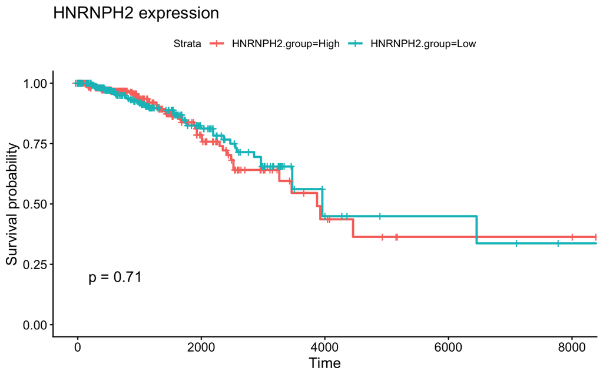

```r
ggsurvplot(fit_2, data=df, pval=T, title="HNRNPH2 expression")
```

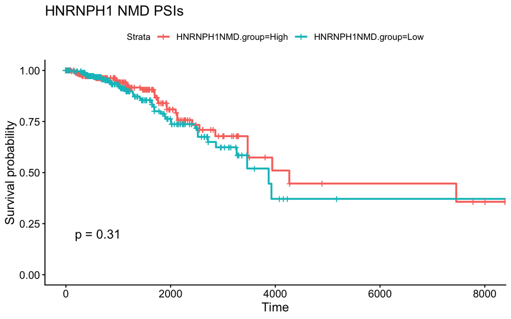

```r
ggsurvplot(fit_1nmd, data=dfnmd, pval=T, title="HNRNPH1 NMD PSIs")
```

```r
# Cox Proportional Hazards Model
fulldf <- left_join(df, dfnmd, by="tcgaPatientBarcode")
cox <- coxph(Surv(OS.time.x, OS.event.x) ~ HNRNPH1 + HNRNPH2 + PSI10, data = fulldf)
summary(cox)
```

```
## Call:
## coxph(formula = Surv(OS.time.x, OS.event.x) ~ HNRNPH1 + HNRNPH2 +
##     PSI10, data = fulldf)
##
##   n= 1383, number of events= 278
##    (10 observations deleted due to missingness)
##
##            coef exp(coef) se(coef)     z Pr(>|z|)
## HNRNPH1 0.14707   1.15844  0.14108 1.042    0.297
## HNRNPH2 0.19857   1.21965  0.14031 1.415    0.157
## PSI10   0.04606   1.04714  0.06699 0.688    0.492
##
##         exp(coef) exp(-coef) lower .95 upper .95
## HNRNPH1     1.158     0.8632    0.8786     1.527
## HNRNPH2     1.220     0.8199    0.9264     1.606
## PSI10       1.047     0.9550    0.9183     1.194
##
## Concordance= 0.512  (se = 0.024 )
## Likelihood ratio test= 2.5  on 3 df,   p=0.5
## Wald test            = 2.47  on 3 df,   p=0.5
## Score (logrank) test = 2.46  on 3 df,   p=0.5
```

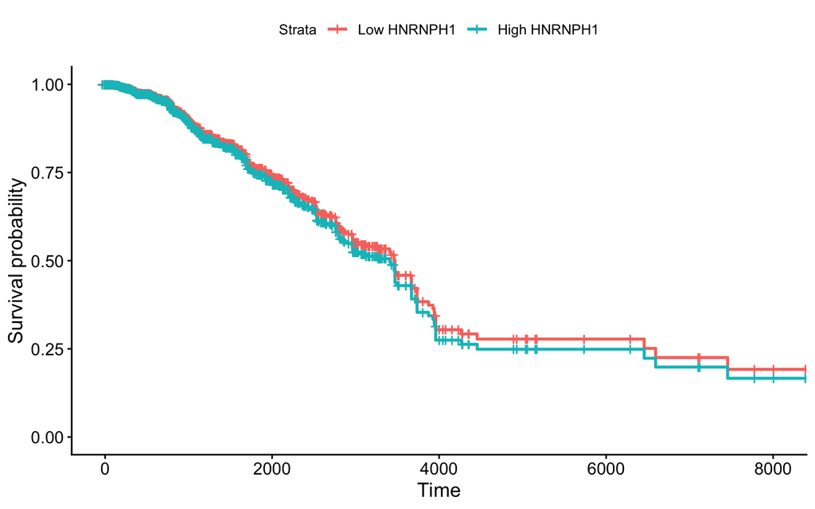

```r
newdat <- data.frame(HNRNPH1 = c(quantile(fulldf$HNRNPH1, 0.25, na.rm=T), quantile(fulldf$HNRNPH1, 0.75, na.rm=T)),
                     HNRNPH2 = median(fulldf$HNRNPH2, na.rm=T),
                     PSI10 = median(fulldf$PSI10, na.rm=T))
fit <- survfit(cox, newdata = newdat)
ggsurvplot(fit, data = fulldf, conf.int=F, legend.labs = c("Low HNRNPH1", "High HNRNPH1"))
```

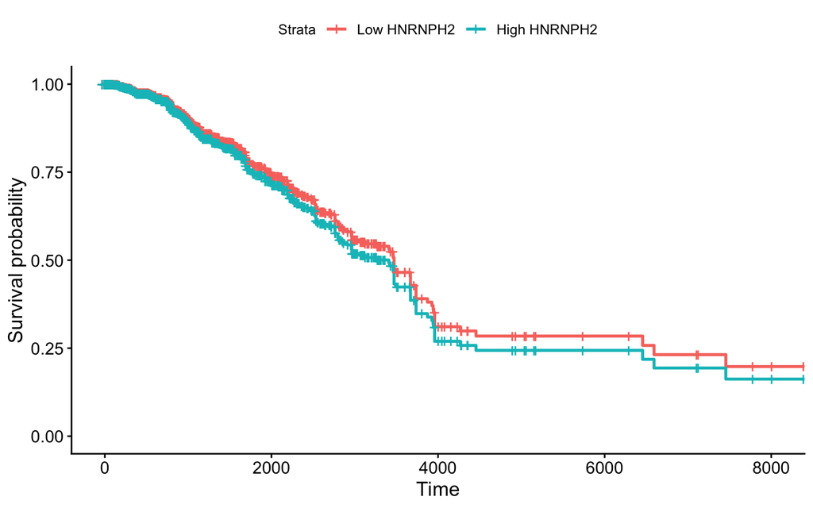

```r
newdat <- data.frame(HNRNPH1 = median(fulldf$HNRNPH1, na.rm=T),
                     HNRNPH2 = c(quantile(fulldf$HNRNPH2, 0.25, na.rm=T), quantile(fulldf$HNRNPH2, 0.75, na.rm=T)),
                     PSI10 = median(fulldf$PSI10, na.rm=T))
fit <- survfit(cox, newdata = newdat)
ggsurvplot(fit, data = fulldf, conf.int=F, legend.labs = c("Low HNRNPH2", "High HNRNPH2"))
```

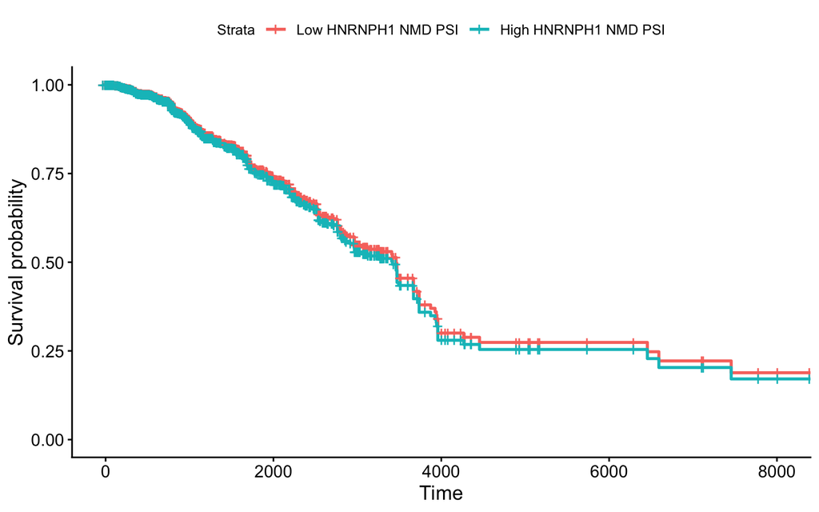

```r
newdat <- data.frame(HNRNPH1 = median(fulldf$HNRNPH1, na.rm=T),
                     HNRNPH2 = median(fulldf$HNRNPH2, na.rm=T),
                     PSI10 = c(quantile(fulldf$PSI10, 0.25, na.rm=T), quantile(fulldf$PSI10, 0.75, na.rm=T)))
fit <- survfit(cox, newdata = newdat)
ggsurvplot(fit, data = fulldf, conf.int=F, legend.labs = c("Low HNRNPH1 NMD PSI", "High HNRNPH1 NMD PSI"))
```

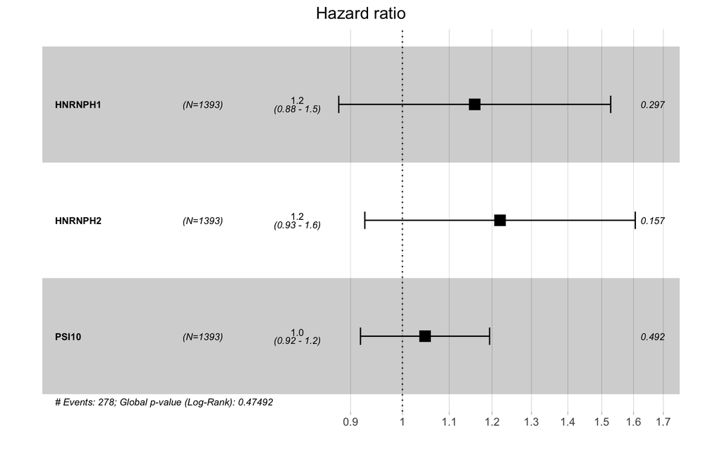

```r
ggforest(cox, data = fulldf)
```